# 6. Prepare Spruce Input

Will Hannon

28 April, 2023

The goal of this notebook is look at how the haplotype frequencies add up in each compartment. In addition to this, we want to prepare the data for SPRUCE to see if we can use this frequency information to fit plausible phylogenetic trees. **The output of this notebook is a file formatted for the tool `MACHINA` and it’s tree-building algorithm `SPRUCE`.**

```r
## ==== File paths input data ==== ##

if (exists("snakemake")) {

  # Data from lofreq and varscan labeled with subclonal haplotypes
  updated.data = snakemake@params[["incsv"]]

  # Depth per position
  merged.depth = snakemake@input[[1]]

  # Original unfiltered variant calls
  variant.data = snakemake@params[['rawvariants']]

} else {

  # Data from lofreq and varscan labeled with subclonal haplotypes
  updated.data = "../../results/variants/validated_variants.csv"

  # Depth per position
  merged.depth = "../../results/coverage/merged.depth"

  # Original unfiltered variant calls
  variant.data = "../../results/variants/variants.csv"

}
```

```r
## ==== File paths output data ==== ##

if (exists("snakemake")) {

  # Data formatted for MACHINA/SPRUCE
  machina.input.data = snakemake@params[["spruce"]]

  # Path to save figures
  figure.dir = paste0(snakemake@params[['figures']], "/")

} else {

  # Data formatted for MACHINA/SPRUCE
  machina.input.data = "../../results/variants/spruce_input.tsv"

  # Path to save figures
  figure.dir = "../../results/figures/"

}

# Make the figure directory if it doesn't exist
if (!file.exists(figure.dir)) {
  dir.create(figure.dir, recursive = TRUE)
  print("Directory created.")
} else {
  print("Directory already exists.")
}
```

```
## [1] "Directory already exists."
```

## Frequency by Compartment

One question is how the sum of frequencies of each haplotype looks across the tissue specimens. These shouldn’t sum to more than the average frequency of their lineage (`Genome 1` or `Genome 2`). If they do, that means that some of these haplotypes could be descended from one another.

### Genome 2

What does this look like for Genome 2?

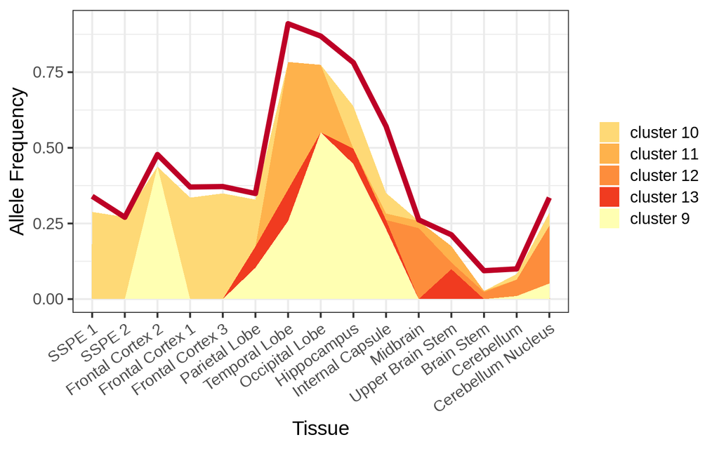

### Genome 1

What about Genome 1?

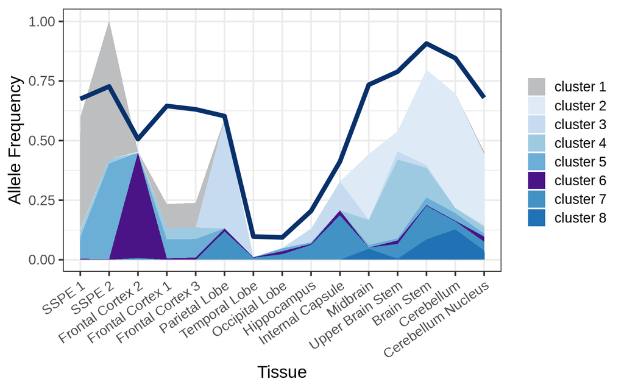

In Genome 1 there is a violation in SSPE 2 where two clusters sum to a frequency greater than the frequency of Genome 1 in that specimen. This gives us reason to suspect that these clusters are related in some way. In particular, that cluster 5 is on the background of cluster 1. However, we want to confirm these relationships as best as possible using a systematic approach with the algorithm SPRUCE. Using SPRUCE, we can fit trees to the data based on haplotype frequency. Then, we can use bridging reads to filter out trees that link haplotypes that we know must be forbidden based on the overlapping reads.

## Prepare data for Spruce

We need to format the input data for SPRUCE. To do this, we need to have a lower and upper bound for the haplotype frequency in each compartment. To calculate this, one approach is to use the min and max allele frequency of SNPs in each compartment for each haplotype as the lower and upper bounds.

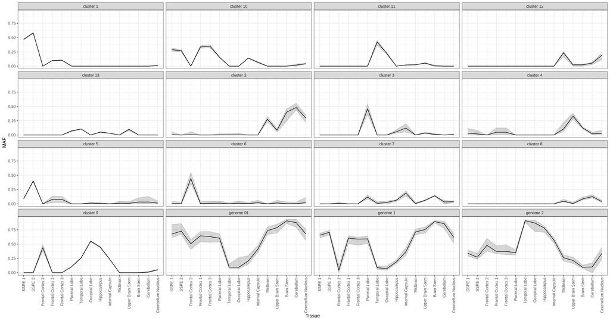

```r
# Read in the original variant calls
variant.df = read_csv(variant.data, show_col_types = F)

# Add in the depth data
merged.depth.df = fread(merged.depth) %>%
  select(!V1)

# Join the depth data to the allele frequencies
expanded.depth.df = expanded.df %>%
  select(!DP) %>%
  left_join(., distinct(select(labeled.df, POS, SNP, Tissue, Accession)), by = c("SNP", "Tissue")) %>%
  left_join(., merged.depth.df, by = c("POS", "Accession")) %>%
  # Rename the UBS
  mutate(Tissue = if_else(Tissue == "UBS", "Upper Brain Stem", Tissue))

# C4573T is missing in the Cerebellum due to low depth filters. Add this back in.
C4573T.AF = variant.df %>%
  mutate(SNP = paste(REF, POS, ALT, sep = "")) %>%
  filter(SNP == "C4573T" & Tissue == 'Cerebellum') %>%
  pull(AF)

expanded.depth.df = expanded.depth.df %>%
  mutate(AF = case_when(
    SNP == "C4573T" & Tissue == 'Cerebellum' ~ C4573T.AF,
    TRUE ~ AF
  ))

# Make tissue index
Tissue_index = expanded.depth.df %>%
  select(Tissue) %>%
  distinct() %>%
  mutate(tind = 1:n() - 1)

# Make cluster index
Cluster_index = expanded.depth.df %>%
  select(Haplotype) %>%
  distinct() %>%
  filter(!Haplotype %in% c("both", "subclonal")) %>%
  mutate(cind = 1:n() - 1) %>%
  add_row(Haplotype = "Anc", cind = 16)

# Calculate the MAF along with some variance (in this case the min and max in each compartment) for wiggle room.
spruce.data.df = expanded.depth.df %>%
  filter(!Haplotype %in% c("both", "subclonal")) %>%
  group_by(Haplotype, Tissue) %>%
  # use this formulation for cluster allele frequency, because it puts less weight on low read depth positions
  summarize(MAF = mean(AF),
            min = min(AF),
            max = max(AF)) %>%
  # MACHINA wants an upper and lower bound on what the allele frequencies are
  mutate(lb = pmax(0, min), ub = pmin(1, max))

spruce.data.df %>%
  ggplot(aes(x = factor(Tissue, levels = tissue.order), y = MAF, group = Haplotype, ymin=lb, ymax=ub)) +
    geom_ribbon(alpha=0.2, colour = "grey") +
    geom_line() +
    facet_wrap(~Haplotype) +
    xlab("Tissue") +
    theme_bw() +
    theme(axis.text.x = element_text(angle = 90, vjust = 0.5, hjust=1))
```

Another approach to calculate the lower and upper bound on mean haplotype frequency is to apply some downscale factor to depth and then use depth to calculate the variance. Let’s try this below.

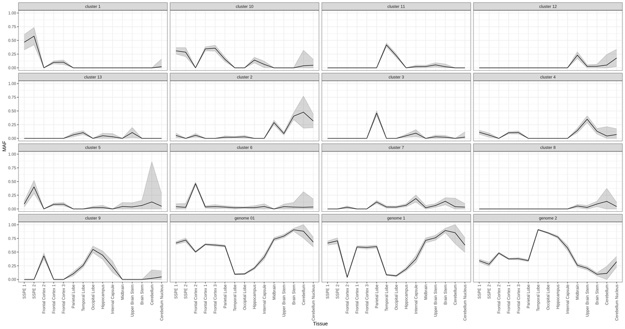

```r
down.wieght = 0.0005

spruce.data.alt.df = expanded.df %>%
  group_by(Haplotype, Tissue) %>%
  filter(!Haplotype %in% c("both", "subclonal")) %>%
  # Add a psuedo-count to depth
  mutate(DP = DP + 1) %>%
  # Add back the uncovered G1 SNP
  mutate(AF = case_when(
    SNP == "C4573T" & Tissue == 'Cerebellum' ~ C4573T.AF,
    TRUE ~ AF
  )) %>%
  # Rename the UBS
  mutate(Tissue = if_else(Tissue == "UBS", "Upper Brain Stem", Tissue)) %>%
  # use this formulation for cluster allele frequency, because it puts less weight on low read depth positions
  summarize(MAF = sum(AF * DP)/sum(DP),
            var = sqrt(MAF * (1 - MAF) / (sum(DP) * down.wieght))) %>%
  # MACHINA wants an upper and lower bound on what the allele frequencies are
  mutate(lb = pmax(0, MAF - var), ub = pmin(1, MAF + var))

spruce.data.alt.df %>%
  ggplot(aes(x = factor(Tissue, levels = tissue.order), y = MAF, group = Haplotype, ymin=lb, ymax=ub)) +
    geom_ribbon(alpha=0.2, colour = "grey") +
    geom_line() +
    facet_wrap(~Haplotype) +
    xlab("Tissue") +
    theme_bw() +
    theme(axis.text.x = element_text(angle = 90, vjust = 0.5, hjust=1))
```

Currently, it’s not clear exactly which method is optimal. One approach takes into account the depth in the tissue to get variance, the other takes into account the variance in frequency in each tissue. We’ll stick with the frequency-based approach for now.

```r
# Add the ancestor back in or it won't connect g1 and g2
with.anc.df = bind_rows(spruce.data.df,
                    Tissue_index %>%
                      select(-tind) %>%
                      mutate(Haplotype = "Anc", MAF = NA, SD = NA, lb = 1, ub = 1)
                    )

# Merge the average cluster frequencies with the index information that spruce wants
spruce.output = left_join(left_join(with.anc.df, Tissue_index), Cluster_index) %>%
    ungroup() %>%
    # need to substitute out spaces
    mutate(Tissue = gsub(" ", "_", Tissue)) %>%
    mutate(Haplotype = gsub(" ", "_", Haplotype)) %>%
    mutate(sind = tind, sample = Tissue) %>%
    select(tind, Tissue, sind, sample, cind, Haplotype, lb, ub)  %>%
    arrange(tind, cind) %>%
    mutate(ub = pmax(lb, ub))
head(spruce.output) %>%
  kable(., caption = "Data for SPRUCE")
```

Data for SPRUCE

| tind | Tissue | sind | sample | cind | Haplotype | lb | ub |
| --- | --- | --- | --- | --- | --- | --- | --- |
| 0 | Temporal_Lobe | 0 | Temporal_Lobe | 0 | genome_2 | 0.8837 | 0.9231 |
| 0 | Temporal_Lobe | 0 | Temporal_Lobe | 1 | cluster_7 | 0.0000 | 0.0350 |
| 0 | Temporal_Lobe | 0 | Temporal_Lobe | 2 | genome_1 | 0.0604 | 0.1157 |
| 0 | Temporal_Lobe | 0 | Temporal_Lobe | 3 | cluster_2 | 0.0000 | 0.0207 |
| 0 | Temporal_Lobe | 0 | Temporal_Lobe | 4 | cluster_9 | 0.2536 | 0.2627 |
| 0 | Temporal_Lobe | 0 | Temporal_Lobe | 5 | genome_01 | 0.0659 | 0.1520 |

```r
## ==== Write Output data ==== ##

# Header needs to specify these variables
write(
  paste0(
    nrow(Tissue_index),
    "\n", nrow(Tissue_index),
    "\n", nrow(Cluster_index),
    "\n#", collapse = "" ),
  machina.input.data
)

# Then write the cluster frequencies
write.table(spruce.output,
            machina.input.data,
            sep = "\t",
            quote = FALSE,
            row.names = FALSE,
            col.names = FALSE,
            append = TRUE)

# Run this command
paste0("generatemutationtrees ", machina.input.data, " > ", "../../results/variants/spruce_output.tsv")
```

```
## [1] "generatemutationtrees results/variants/spruce_input.tsv > ../../results/variants/spruce_output.tsv"
```